# Classificação

## Tópicos Especiais em Inteligência Artificial

### Trabalho I - Classificação

#### Alunos: Lucas Ribeiro Ferreira e Letícia Garcez

##### Descrição dos dados:

Cada dado é um exemplo de uma mão de poker com cinco cartas tiradas de um deck normal com 52. Cada carta é descrita com dois atributos (Naipe e Rank), com um total de 10 atributos preditivos. Esse é o atributo Classe que descreve a "mão de poker". A ordem das cartas é importante, esse é o porquê existem 480 possibilidades de mãos Royal Flush em comparação com 4.

1) S1 "Suit of card #1"  
Ordinal (1-4) representing {Hearts, Spades, Diamonds, Clubs}  
2) C1 "Rank of card #1"  
Numerical (1-13) representing (Ace, 2, 3, ... , Queen, King)  
3) S2 "Suit of card #2"  
Ordinal (1-4) representing {Hearts, Spades, Diamonds, Clubs}  
4) C2 "Rank of card #2"  
Numerical (1-13) representing (Ace, 2, 3, ... , Queen, King)  
5) S3 "Suit of card #3"  
Ordinal (1-4) representing {Hearts, Spades, Diamonds, Clubs}  
6) C3 "Rank of card #3"  
Numerical (1-13) representing (Ace, 2, 3, ... , Queen, King)  
7) S4 "Suit of card #4"  
Ordinal (1-4) representing {Hearts, Spades, Diamonds, Clubs}  
8) C4 "Rank of card #4"  
Numerical (1-13) representing (Ace, 2, 3, ... , Queen, King)  
9) S5 "Suit of card #5"  
Ordinal (1-4) representing {Hearts, Spades, Diamonds, Clubs}  
10) C5 "Rank of card 5"  
Numerical (1-13) representing (Ace, 2, 3, ... , Queen, King)  
11) CLASS "Poker Hand"  
Ordinal (0-9)  
0: Nothing in hand; not a recognized poker hand  
1: One pair; one pair of equal ranks within five cards  
2: Two pairs; two pairs of equal ranks within five cards  
3: Three of a kind; three equal ranks within five cards  
4: Straight; five cards, sequentially ranked with no gaps  
5: Flush; five cards with the same suit  
6: Full house; pair + different rank three of a kind  
7: Four of a kind; four equal ranks within five cards  
8: Straight flush; straight + flush  
9: Royal flush; {Ace, King, Queen, Jack, Ten} + flush

#### Class Distribution:

The first percentage in parenthesis is the representation within the training set. The second is the probability in the full domain.

```
  Training set:

  0. Nothing in hand, 12493 instances (49.95202% / 50.117739%)
  1. One pair, 10599 instances, (42.37905% / 42.256903%)
  2. Two pairs, 1206 instances, (4.82207% / 4.753902%)
  3. Three of a kind, 513 instances, (2.05118% / 2.112845%)
  4. Straight, 93 instances, (0.37185% / 0.392465%)
  5. Flush, 54 instances, (0.21591% / 0.19654%)
  6. Full house, 36 instances, (0.14394% / 0.144058%)
  7. Four of a kind, 6 instances, (0.02399% / 0.02401%)
  8. Straight flush, 5 instances, (0.01999% / 0.001385%)
  9. Royal flush, 5 instances, (0.01999% / 0.000154%)

The Straight flush and Royal flush hands are not as representative of
the true domain because they have been over-sampled. The Straight flush
is 14.43 times more likely to occur in the training set, while the
Royal flush is 129.82 times more likely.

Total of 25010 instances in a domain of 311,875,200.

Testing set:

The value inside parenthesis indicates the representation within the test
set as compared to the entire domain. 1.0 would be perfect representation,
while <1.0 are under-represented and >1.0 are over-represented.

0. Nothing in hand, 501209 instances,(1.000063)
1. One pair, 422498 instances,(0.999832)
2. Two pairs, 47622 instances, (1.001746)
3. Three of a kind, 21121 instances, (0.999647)
4. Straight, 3885 instances, (0.989897)
5. Flush, 1996 instances, (1.015569)
6. Full house, 1424 instances, (0.988491)
7. Four of a kind, 230 instances, (0.957934)
8. Straight flush, 12 instances, (0.866426)
9. Royal flush, 3 instances, (1.948052)
```

### Imports

```python
import pandas as pd
import numpy as np
from sklearn import tree
from sklearn.neural_network import MLPClassifier
from sklearn import metrics
from sklearn import svm
import itertools
import matplotlib.pyplot as plt
from sklearn.preprocessing import label_binarize
# from IPython.display import Image
# import pydotplus
```

### Funções de apoio

1. plot_confusion_matrix: Função usada para fazer o plot da matriz de confução
2. trues_by_class: Função utilizada para separar os gabaritos por classe. Inserindo no index o valor 1 se X é o valor da classe e 0 se não é o valor da classe.  
   Cria tantos vetores colunas quanto classes.  
   Ex:  
   Vetor Coluna: [1 2 4 3]  
   Saida: [1 0 0 0] [0 1 0 0] [0 0 0 1] [0 0 1 0]

```python
def plot_confusion_matrix(cm, classes,
                          normalize=False,
                          title='Confusion matrix',
                          cmap=plt.cm.Blues):
    """
    This function prints and plots the confusion matrix.
    Normalization can be applied by setting `normalize=True`.
    """
    cm = cm.astype('float') / cm.sum(axis=1)[:, np.newaxis]
    plt.imshow(cm, interpolation='nearest', cmap=cmap)
    plt.title(title)
    plt.colorbar()
    tick_marks = np.arange(len(classes))
    plt.xticks(tick_marks, classes, rotation=45)
    plt.yticks(tick_marks, classes)

    if normalize:
        cm = cm.astype('float') / cm.sum(axis=1)[:, np.newaxis]
        print("Normalized confusion matrix")
    else:
        print('Confusion matrix, without normalization')

    print(cm)

    thresh = cm.max() / 2.
    for i, j in itertools.product(range(cm.shape[0]), range(cm.shape[1])):
        plt.text(j, i, float("{0:.2f}".format(cm[i, j])),
                 horizontalalignment="center",
                 color="black" if cm[i, j] > thresh else "black")

    plt.tight_layout()
    plt.ylabel('True label')
    plt.xlabel('Predicted label')

def trues_by_class(array):
    index_not_class = [np.where(array != 0),
                     np.where(array != 1),
                     np.where(array != 2),
                     np.where(array != 3),
                     np.where(array != 4),
                     np.where(array != 5),
                     np.where(array != 6),
                     np.where(array != 7),
                     np.where(array != 8),
                     np.where(array != 9)
                    ]
    index_class = [np.where(array == 0),
                     np.where(array == 1),
                     np.where(array == 2),
                     np.where(array == 3),
                     np.where(array == 4),
                     np.where(array == 5),
                     np.where(array == 6),
                     np.where(array == 7),
                     np.where(array == 8),
                     np.where(array == 9)
                    ]
    aux_array = np.copy(array)
    aux_array[index_not_class[0]] = 2
    aux_array[index_class[0]] = 1
    aux_array[index_not_class[0]] = 0
    trues_by_class = [aux_array]
    for i in range(9):
        j = i+1
        aux_array = np.copy(array)
        aux_array[index_not_class[j]] = 0
        aux_array[index_class[j]] = 1
        trues_by_class = np.append(trues_by_class, [aux_array], axis = 0)
    return trues_by_class
```

Nomes das classes em seus respectivos indexes:

```python
class_names = ["None", "One Pair", "Two Pairs", "Tree Of A Kind", "Straight","Flush", "Full House", "Four Of a Kind", "Straight flush", "Royal flush"  ]
```

### Leitura dos datasets:

#### Leitura dos dados de treino:

```python
training_data = pd.read_csv('data/poker-hand-training-true.data', header= None)
X = training_data.loc[:, 0:9]
Y = training_data.loc[:, 10:10]
training_data.head()
```

|  | 0 | 1 | 2 | 3 | 4 | 5 | 6 | 7 | 8 | 9 | 10 |
| --- | --- | --- | --- | --- | --- | --- | --- | --- | --- | --- | --- |
| 0 | 1 | 10 | 1 | 11 | 1 | 13 | 1 | 12 | 1 | 1 | 9 |
| 1 | 2 | 11 | 2 | 13 | 2 | 10 | 2 | 12 | 2 | 1 | 9 |
| 2 | 3 | 12 | 3 | 11 | 3 | 13 | 3 | 10 | 3 | 1 | 9 |
| 3 | 4 | 10 | 4 | 11 | 4 | 1 | 4 | 13 | 4 | 12 | 9 |
| 4 | 4 | 1 | 4 | 13 | 4 | 12 | 4 | 11 | 4 | 10 | 9 |

##### Lentura dos dados de teste:

```python
test_data = pd.read_csv('data/poker-hand-testing.data', header= None)
test_X = test_data.loc[:, 0:9]
true_Y = test_data.loc[:, [10]]
test_data.head()
```

|  | 0 | 1 | 2 | 3 | 4 | 5 | 6 | 7 | 8 | 9 | 10 |
| --- | --- | --- | --- | --- | --- | --- | --- | --- | --- | --- | --- |
| 0 | 1 | 1 | 1 | 13 | 2 | 4 | 2 | 3 | 1 | 12 | 0 |
| 1 | 3 | 12 | 3 | 2 | 3 | 11 | 4 | 5 | 2 | 5 | 1 |
| 2 | 1 | 9 | 4 | 6 | 1 | 4 | 3 | 2 | 3 | 9 | 1 |
| 3 | 1 | 4 | 3 | 13 | 2 | 13 | 2 | 1 | 3 | 6 | 1 |
| 4 | 3 | 10 | 2 | 7 | 1 | 2 | 2 | 11 | 4 | 9 | 0 |

#### Separarando gabarito por classe

```python
true_Y_by_class = trues_by_class(true_Y)
true_Y_by_class[0]
```

```
array([[1],
       [0],
       [0],
       ...,
       [0],
       [0],
       [0]], dtype=int64)
```

#### Preprocessando o dataset

Devido a natureza categórica de alguns atributos, é necessário ser feita um preprocessamento dos dados para binarizar esses atributos.

Faremos uso da função *label_binarize* do scikit-learn para ajudar nesse processo.

As colunas categóricas são as que fazem referencia ao Naipe das cartas, que pode ser 1 (Hearts), 2 (Spades), 3 (Diamonds), 4 (Clubs), e se encontram nas colunas 0, 2, 4, 6, 8 do dataset.

Durante a binarização os valores 1, 2, 3, 4 serão transformados da seguinte forma:  
1 = 1 0 0 0  
2 = 0 1 0 0  
3 = 0 0 1 0  
4 = 0 0 0 1

Ao final do processo de binarização, cada uma dessas colunas terá se tornado outras quatro segundo a regra explicada anteriormente.

No output anterior temos um exemplo do dataset de teste original. No proximo teremos um exemplo do dataset de teste binarizado.

```python
def binarize_categorical_columns(data):
    for j in range(5):
        colum_index = j * 2 + 3*j
        binarized_colum = label_binarize(data[:, [colum_index]], classes=[1, 2, 3, 4], pos_label= 1, neg_label= 0)
        data = np.delete(data, colum_index, 1)
        for i in range(binarized_colum.shape[1]):
            new_index_colum = colum_index+i
            data = np.insert(data, new_index_colum, binarized_colum[:, i] , axis=1)
    return data

bin_X = binarize_categorical_columns(np.array(X))
bin_test_X = binarize_categorical_columns(np.array(test_X))

bin_test_X[0:4, :]
```

```
array([[ 1,  0,  0,  0,  1,  1,  0,  0,  0, 13,  0,  1,  0,  0,  4,  0,  1,
         0,  0,  3,  1,  0,  0,  0, 12],
       [ 0,  0,  1,  0, 12,  0,  0,  1,  0,  2,  0,  0,  1,  0, 11,  0,  0,
         0,  1,  5,  0,  1,  0,  0,  5],
       [ 1,  0,  0,  0,  9,  0,  0,  0,  1,  6,  1,  0,  0,  0,  4,  0,  0,
         1,  0,  2,  0,  0,  1,  0,  9],
       [ 1,  0,  0,  0,  4,  0,  0,  1,  0, 13,  0,  1,  0,  0, 13,  0,  1,
         0,  0,  1,  0,  0,  1,  0,  6]], dtype=int64)
```

### Realizando predição

#### Árvore de Decisão

Decidimos usar o algoritmo de Árvore de Decisão pois testamos alguns outros e percebemos que a Árvore de Decisão se comporta um pouco melhor com esse problema. Isso pode ser explicado devido a natureza do problema ser sobre regras de um jogo. Um algoritmo que gera uma arvore de regras para decidir a classe do dado nos pareceu que se comportaria melhor.

Nos proximos passos, criamos uma 'instancia' do algorímo, foi feito o treinamento e a predição em seguida. Após isso, separamos a predição em predições por classe de maneira analoga à separação por classes do gabarito.

```python
clf = tree.DecisionTreeClassifier()
clf = clf.fit(bin_X, Y)
predict_Y = clf.predict(bin_test_X)
predict_Y_by_class = trues_by_class(predict_Y)
```

```python
# dot_data = tree.export_graphviz(clf, out_file=None,
# #                          feature_names=["n1_1","n1_2","n1_3","n1_4","r1","n2_1","n2_2","n2_3","n2_4","r2"],
#                          class_names=class_names,
#                          filled=True, rounded=True,
#                          special_characters=True)
# graph = pydotplus.graph_from_dot_data(dot_data)
# Image(graph.create_png())
```

### Métricas de Validação

Abaixo veremos uma análise em cima da predição e do gabarito para poder dizer se a predição foi bem sucessida ou não.

Usaremos as seguintes métricas: matriz de confusão, acurácia, precisão, recall e f1

Primeiro temos uma análise classe por classe e posteriormente veremos uma análise global.

### Métricas de Validação - Classe 0 (None)

#### A classe:

A classe 0 é referente a mão que não possui nenhuma combinação de cartas que caracteriza uma mão de poker. Em resumo, é a classe "não-classe", pois ela se dá quando nenhum das outras foi possível.

#### Matriz de Confusão - Classe 0 (None)

Abaixo temos os resultados da matriz de confusão.

```python
class_now = 0
trues_now = true_Y_by_class[class_now]
predics_now = predict_Y_by_class[class_now]
```

```
Confusion matrix, without normalization
[[ 0.6   0.4 ]
 [ 0.43  0.57]]
```

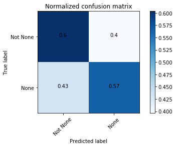

```python
# cnf_matrix = confusion_matrix(true_Y, predict_Y)
cnf_matrix = metrics.confusion_matrix(trues_now, predics_now)
np.set_printoptions(precision=2)
# Plot non-normalized confusion matrix
plt.figure()
plot_confusion_matrix(cnf_matrix, classes=["Not None", "None"], normalize=False,
                      title='Normalized confusion matrix')
plt.show()
```

Através dessa matriz de confusão podemos ver que modelo foi capaz de acertar um pouco mais da metade em ambas possibilidades. Quando o gabarito era *None* (classe) ele preveu corretamente em 57% das vezes e quando era *Not None* (Não-Classe) ele acertou que a classe *não* era *None* em 60% das vezes. Porém, em um pouco mais de 40% das vezes ele preveu sendo *None* quando era alguma outra classe e o mesmo caso para quando preveu ser qualquer outra e era *None*

#### Acurácia - Classe 0 (None)

```python
metrics.accuracy_score(trues_now, predics_now)
```

```
0.58431200000000005
```

Com um taxa de acurácia de quase 60%, podemos ver que nosso modelo está com uma quantidade alta de falsos positivos e falsos negativos, mas ainda temos a maior porcentagem de verdadeiro positivos e negativos.

#### Precisão - Classe 0 (None)

```python
metrics.precision_score(trues_now, predics_now)
```

```
0.58886757514480303
```

Com uma precisão de somente quase 60% podemos afirmar que muitas das vezes que o nosso modelo afirmou que um dado era da classe None, era de outra classe.

#### Recall - Classe 0 (None)

```python
metrics.recall_score(trues_now, predics_now)
```

```
0.56532504404350281
```

Com um recall de quase 60% podemos afirmar que acertamos a maior parte dos dados da Classe None. Mas ainda ficaram muitos que o nosso modelo rotulou como sendo de alguma outra classe que não None.

#### f1 Score - Classe 0 (None)

```python
metrics.f1_score(trues_now, predics_now)
```

```
0.57685620635599266
```

Vimos anteriormente que o Recall e a Precisão não estão tão discrepantes, o que nos faz poder afirmar que o nosso f1 score para a classe None está próximo da media padrão entre o Recall e a Precisão.

### Métricas de Validação - Classe 1 (One Pair)

#### A classe:

A classe 1 é referente a mão que possui nenhuma combinação de cartas que caracteriza a mão de poker chamada "Um par". Como o nome ja diz, essa classe se dá quando o jogador possui duas cartas de mesmo **rank** (um par) entre as cinco de sua mão.

#### Matriz de Confusão - Classe 1 (One Pair)

Abaixo temos os resultados da matriz de confusão.

```python
class_now = 1
trues_now = true_Y_by_class[class_now]
predics_now = predict_Y_by_class[class_now]
```

```
Confusion matrix, without normalization
[[ 0.61  0.39]
 [ 0.53  0.47]]
```

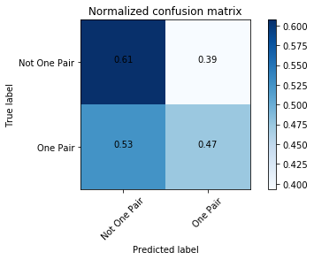

```python
# cnf_matrix = confusion_matrix(true_Y, predict_Y)
cnf_matrix = metrics.confusion_matrix(trues_now, predics_now)
np.set_printoptions(precision=2)
# Plot non-normalized confusion matrix
plt.figure()
plot_confusion_matrix(cnf_matrix, classes=["Not "+class_names[class_now], class_names[class_now]], normalize=False,
                      title='Normalized confusion matrix')
plt.show()
```

#### Acurácia

```python
metrics.accuracy_score(trues_now, predics_now)
```

```
0.55096800000000001
```

Com um taxa de acurácia de próxima, mas maior que 50%, podemos dizer que nosso modelo está com uma quantidade alta de falsos positivos e falsos negativos, mas ainda temos a maior porcentagem de verdadeiro positivos e negativos.

#### Precisão

```python
metrics.precision_score(trues_now, predics_now)
```

```
0.46894210735772646
```

Com uma precisão abaixo de 50% podemos afirmar que muitas das vezes que o nosso modelo afirmou que um dado era da classe, era, na verdade, de outra classe.

#### Recall

```python
metrics.recall_score(trues_now, predics_now)
```

```
0.47412768817840556
```

Com um recall abaixo de 50% podemos afirmar que erramos a maior parte dos dados da classe.

#### f1 Score

```python
metrics.f1_score(trues_now, predics_now)
```

```
0.47152064100330954
```

Vimos anteriormente que o Recall e a Precisão não estão muito discrepantes, o que nos faz poder afirmar que o nosso f1 score para a classe está próximo da media padrão entre o Recall e a Precisão.

### Métricas de Validação - Classe 2 (Two Pairs)

#### A classe:

A classe 2 é referente a mão que possui nenhuma combinação de cartas que caracteriza a mão de poker chamada "Dois pares". Como o nome ja diz, essa classe se dá quando o jogador possui duas duas cartas de mesmo **rank** (dois pares) entre as cinco de sua mão.

#### Matriz de Confusão

Abaixo temos os resultados da matriz de confusão.

```python
class_now = 2
trues_now = true_Y_by_class[class_now]
predics_now = predict_Y_by_class[class_now]
```

```
Confusion matrix, without normalization
[[ 0.95  0.05]
 [ 0.87  0.13]]
```

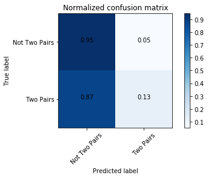

```python
# cnf_matrix = confusion_matrix(true_Y, predict_Y)
cnf_matrix = metrics.confusion_matrix(trues_now, predics_now)
np.set_printoptions(precision=2)
# Plot non-normalized confusion matrix
plt.figure()
plot_confusion_matrix(cnf_matrix, classes=["Not "+class_names[class_now], class_names[class_now]], normalize=False,
                      title='Normalized confusion matrix')
plt.show()
```

Com a parte mais escura do grafico ficando a esquerda, podemos ver que o modelo na maior parte das vezes preveu que a classe não era a classe em questão. Conseguiu acertar bastante quando não era realmente, mas errou na maior parte das vezes quando era da classe.

Pode se concluir que o modelo chutou muito pouco que um exemplo do dataset era dessa classe.

#### Acurácia

```python
metrics.accuracy_score(trues_now, predics_now)
```

```
0.90635299999999996
```

Com um taxa de acurácia de um pouco mais de 90%, temos a impressão de que o modelo conseguiu acertar muito nessa classe. Mas como pudemos observar na matriz de confusão e vamos observar nas próximas métricas, isso muito se deu por ter muito exemplos que não fazem parte dessa classe e o modelo ter tipo uma porcentagem enorme de chutes em não ser da classe.

#### Precisão

```python
metrics.precision_score(trues_now, predics_now)
```

```
0.10408602150537634
```

#### Recall

```python
metrics.recall_score(trues_now, predics_now)
```

```
0.12704212338834991
```

Com um recall abaixo de 15% podemos afirmar que houve um numero exorbitante de falso negativo.

#### f1 Score

```python
metrics.f1_score(trues_now, predics_now)
```

```
0.11442404985484222
```

Corroborando com as métricas anteriores, o f1 está proxímo de 10%.

### Métricas de Validação - Classe 3 (Tree of a Kind)

#### A classe:

A classe 3 é referente a mão que possui uma combinação de cartas que caracteriza a mão de poker chamada "Trinca". Essa classe se dá quando o jogador possui três cartas de mesmo **rank** entre as cinco de sua mão.

#### Matriz de Confusão

Abaixo temos os resultados da matriz de confusão.

```python
class_now = 3
trues_now = true_Y_by_class[class_now]
predics_now = predict_Y_by_class[class_now]
```

```
Confusion matrix, without normalization
[[ 0.98  0.02]
 [ 0.89  0.11]]
```

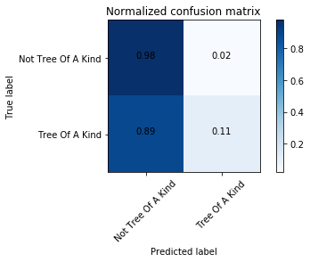

```python
# cnf_matrix = confusion_matrix(true_Y, predict_Y)
cnf_matrix = metrics.confusion_matrix(trues_now, predics_now)
np.set_printoptions(precision=2)
# Plot non-normalized confusion matrix
plt.figure()
plot_confusion_matrix(cnf_matrix, classes=["Not "+class_names[class_now], class_names[class_now]], normalize=False,
                      title='Normalized confusion matrix')
plt.show()
```

Com a parte mais escura do grafico ficando a esquerda, podemos ver que o modelo na maior parte das vezes preveu que a classe não era a classe em questão. Conseguiu acertar bastante quando não era realmente, mas errou na maior parte das vezes quando era da classe.

Pode se concluir que o modelo chutou muito pouco que um exemplo do dataset era dessa classe.

#### Acurácia

```python
metrics.accuracy_score(trues_now, predics_now)
```

```
0.96071399999999996
```

Com um taxa de acurácia acima de 90%, temos a impressão de que o modelo conseguiu acertar muito nessa classe. Mas como pudemos observar na matriz de confusão e vamos observar nas próximas métricas, isso muito se deu por ter muito exemplos que não fazem parte dessa classe no dataset e a predição ter tido uma porcentagem enorme de chutes em não ser da classe.

#### Precisão

```python
metrics.precision_score(trues_now, predics_now)
```

```
0.10457573250903392
```

Com uma precisão próxima de 10% podemos afirmar que o modelo errou muito ao tentar prever a classe. Houve uma quantidade exorbitante de falso positivo em comparação aos verdadeiros positivos..

#### Recall

```python
metrics.recall_score(trues_now, predics_now)
```

```
0.1137256758676199
```

Com um recall abaixo de 15% podemos afirmar que houve um numero exorbitante de falso negativo.

#### f1 Score

```python
metrics.f1_score(trues_now, predics_now)
```

```
0.10895894760716715
```

Corroborando com as métricas anteriores, o f1 está proxímo de 10%.

### Métricas de Validação - Classe 4 (Strainght)

#### A classe:

A classe 4 é referente a mão que possui uma combinação de cartas que caracteriza a mão de poker chamada "Sequencia". Essa classe se dá quando o jogador possui cinco cartas de **rank** em sequencia na sua mão.

#### Matriz de Confusão

Abaixo temos os resultados da matriz de confusão.

```python
class_now = 4
trues_now = true_Y_by_class[class_now]
predics_now = predict_Y_by_class[class_now]
```

```
Confusion matrix, without normalization
[[ 0.99  0.01]
 [ 0.97  0.03]]
```

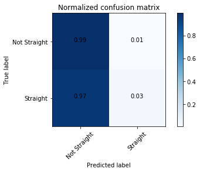

```python
# cnf_matrix = confusion_matrix(true_Y, predict_Y)
cnf_matrix = metrics.confusion_matrix(trues_now, predics_now)
np.set_printoptions(precision=2)
# Plot non-normalized confusion matrix
plt.figure()
plot_confusion_matrix(cnf_matrix, classes=["Not "+class_names[class_now], class_names[class_now]], normalize=False,
                      title='Normalized confusion matrix')
plt.show()
```

Com a parte mais escura do grafico ficando a esquerda, podemos ver que o modelo na maior parte das vezes preveu que a classe não era a classe em questão. Conseguiu acertar bastante quando não era realmente, mas errou na maior parte das vezes quando era da classe.

Pode se concluir que o modelo chutou muito pouco que um exemplo do dataset era dessa classe.

#### Acurácia

```python
metrics.accuracy_score(trues_now, predics_now)
```

```
0.99111800000000005
```

Com um taxa de acurácia de quase 100%, temos a impressão de que o modelo conseguiu acertar muito nessa classe. Mas como pudemos observar na matriz de confusão e vamos observar nas próximas métricas, isso muito se deu por ter muito exemplos que não fazem parte dessa classe no dataset e a predição ter tido uma porcentagem enorme de chutes em não ser da classe.

#### Precisão

```python
metrics.precision_score(trues_now, predics_now)
```

```
0.024728932851436181
```

Com uma precisão próxima de 0% podemos afirmar que o modelo errou muito ao tentar prever a classe. Houve uma quantidade exorbitante de falso positivo em comparação aos verdadeiros positivos.

#### Recall

```python
metrics.recall_score(trues_now, predics_now)
```

```
0.033462033462033462
```

Com um recall de quase 0% podemos afirmar que houve um numero exorbitante de falso negativo.

#### f1 Score

```python
metrics.f1_score(trues_now, predics_now)
```

```
0.028440166265587399
```

Corroborando com as métricas anteriores, o f1 está proxímo de 0%.

### Métricas de Validação - Classe 5 (Flush)

#### A classe:

A classe 5 é referente a mão que possui uma combinação de cartas que caracteriza a mão de poker chamada "Fush". Essa classe se dá quando o jogador possui cinco cartas do mesmo **naipe** na sua mão.

#### Matriz de Confusão

Abaixo temos os resultados da matriz de confusão.

```python
class_now = 5
trues_now = true_Y_by_class[class_now]
predics_now = predict_Y_by_class[class_now]
```

```
Confusion matrix, without normalization
[[ 1.    0.  ]
 [ 0.75  0.25]]
```

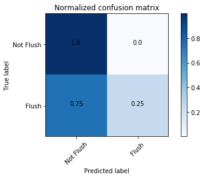

```python
# cnf_matrix = confusion_matrix(true_Y, predict_Y)
cnf_matrix = metrics.confusion_matrix(trues_now, predics_now)
np.set_printoptions(precision=2)
# Plot non-normalized confusion matrix
plt.figure()
plot_confusion_matrix(cnf_matrix, classes=["Not "+class_names[class_now], class_names[class_now]], normalize=False,
                      title='Normalized confusion matrix')
plt.show()
```

Com a parte mais escura do grafico ficando a esquerda, podemos ver que o modelo na maior parte das vezes preveu que a classe não era a classe em questão. Conseguiu acertar bastante quando não era realmente, mas errou na maior parte das vezes quando era da classe.

Pode se concluir que o modelo chutou muito pouco que um exemplo do dataset era dessa classe.

#### Acurácia

```python
metrics.accuracy_score(trues_now, predics_now)
```

```
0.99663000000000002
```

Com um taxa de acurácia de quase 100%, temos a impressão de que o modelo conseguiu acertar muito nessa classe. Mas como pudemos observar na matriz de confusão e vamos observar nas próximas métricas, isso muito se deu por ter muito exemplos que não fazem parte dessa classe no dataset e a predição ter tido uma porcentagem enorme de chutes em não ser da classe.

#### Precisão

```python
metrics.precision_score(trues_now, predics_now)
```

```
0.21134453781512605
```

Com uma precisão próxima de 20% podemos afirmar que o modelo errou muito ao tentar prever a classe. Houve uma quantidade exorbitante de falso positivo em comparação aos verdadeiros positivos.

#### Recall

```python
metrics.recall_score(trues_now, predics_now)
```

```
0.25200400801603207
```

Com um recall de quase 25% podemos afirmar que houve um numero exorbitante de falso negativo.

#### f1 Score

```python
metrics.f1_score(trues_now, predics_now)
```

```
0.22989031078610603
```

Corroborando com as métricas anteriores, o f1 está proxímo de 22%.

### Métricas de Validação - Classe 6 (Full House)

#### Matriz de Confusão

Abaixo temos os resultados da matriz de confusão.

```python
class_now = 6
trues_now = true_Y_by_class[class_now]
predics_now = predict_Y_by_class[class_now]
```

```
Confusion matrix, without normalization
[[ 1.    0.  ]
 [ 0.98  0.02]]
```

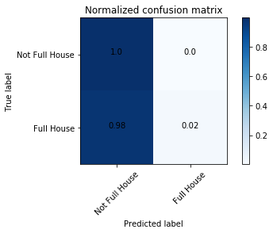

```python
# cnf_matrix = confusion_matrix(true_Y, predict_Y)
cnf_matrix = metrics.confusion_matrix(trues_now, predics_now)
np.set_printoptions(precision=2)
# Plot non-normalized confusion matrix
plt.figure()
plot_confusion_matrix(cnf_matrix, classes=["Not "+class_names[class_now], class_names[class_now]], normalize=False,
                      title='Normalized confusion matrix')
plt.show()
```

Com a parte mais escura do grafico ficando a esquerda, podemos ver que o modelo na maior parte das vezes preveu que a classe não era a classe em questão. Conseguiu acertar bastante quando não era realmente, mas errou na maior parte das vezes quando era da classe.

Pode se concluir que o modelo chutou muito pouco que um exemplo do dataset era dessa classe.

#### Acurácia

```python
metrics.accuracy_score(trues_now, predics_now)
```

```
0.99655499999999997
```

Com um taxa de acurácia de quase 100%, temos a impressão de que o modelo conseguiu acertar muito nessa classe. Mas como pudemos observar na matriz de confusão e vamos observar nas próximas métricas, isso muito se deu por ter muito exemplos que não fazem parte dessa classe no dataset e a predição ter tido uma porcentagem enorme de chutes em não ser da classe.

#### Precisão

```python
metrics.precision_score(trues_now, predics_now)
```

```
0.015812170579779589
```

Com uma precisão próxima de 0% podemos afirmar que o modelo errou muito ao tentar prever a classe. Houve uma quantidade exorbitante de falso positivo em comparação aos verdadeiros positivos.

#### Recall

```python
metrics.recall_score(trues_now, predics_now)
```

```
0.023174157303370788
```

Com um recall de quase 0% podemos afirmar que houve um numero exorbitante de falso negativo.

#### f1 Score

```python
metrics.f1_score(trues_now, predics_now)
```

```
0.01879806322984905
```

Corroborando com as métricas anteriores, o f1 está proxímo de 0%.

### Métricas de Validação - Classe 7 (Four of a Kind)

#### A classe:

A classe 7 é referente a mão que possui uma combinação de cartas que caracteriza a mão de poker chamada "Quadra". Essa classe se dá quando o jogador possui quatro cartas do mesmo **rank** entre as cinco de sua mão.

#### Matriz de Confusão

Abaixo temos os resultados da matriz de confusão.

```python
class_now = 7
trues_now = true_Y_by_class[class_now]
predics_now = predict_Y_by_class[class_now]
```

```
Confusion matrix, without normalization
[[  1.00e+00   4.29e-04]
 [  9.96e-01   4.35e-03]]
```

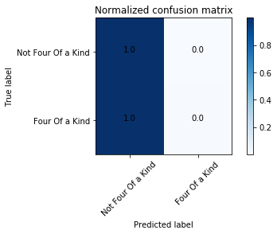

```python
# cnf_matrix = confusion_matrix(true_Y, predict_Y)
cnf_matrix = metrics.confusion_matrix(trues_now, predics_now)
np.set_printoptions(precision=2)
# Plot non-normalized confusion matrix
plt.figure()
plot_confusion_matrix(cnf_matrix, classes=["Not "+class_names[class_now], class_names[class_now]], normalize=False,
                      title='Normalized confusion matrix')
plt.show()
```

Com a parte mais escura do grafico ficando a esquerda, podemos ver que o modelo na maior parte das vezes preveu que a classe não era a classe em questão. Conseguiu acertar bastante quando não era realmente, mas errou na maior parte das vezes quando era da classe.

Pode se concluir que o modelo chutou muito pouco que um exemplo do dataset era dessa classe.

#### Acurácia

```python
metrics.accuracy_score(trues_now, predics_now)
```

```
0.99934199999999995
```

Com um taxa de acurácia de quase 100%, temos a impressão de que o modelo conseguiu acertar muito nessa classe. Mas como pudemos observar na matriz de confusão e vamos observar nas próximas métricas, isso muito se deu por ter muito exemplos que não fazem parte dessa classe no dataset e a predição ter tido uma porcentagem enorme de chutes em não ser da classe.

#### Precisão

```python
metrics.precision_score(trues_now, predics_now)
```

```
0.0023255813953488372
```

Com uma precisão próxima de 0% podemos afirmar que o modelo errou muito ao tentar prever a classe. Houve uma quantidade exorbitante de falso positivo em comparação aos verdadeiros positivos.

#### Recall

```python
metrics.recall_score(trues_now, predics_now)
```

```
0.0043478260869565218
```

Com um recall de quase 0% podemos afirmar que houve um numero exorbitante de falso negativo.

#### f1 Score

```python
metrics.f1_score(trues_now, predics_now)
```

```
0.0030303030303030303
```

Corroborando com as métricas anteriores, o f1 está proxímo de 0%.

### Métricas de Validação - Classe 8 (Strainght Flush)

#### A classe:

A classe 8 é referente a mão que possui uma combinação de cartas que caracteriza a mão de poker chamada "Sequencia do mesmo naipe". Essa classe se dá quando o jogador possui todas as cartas com o **rank** em uma sequencia e todas essas cartas são do mesmo **naipe**.

#### Matriz de Confusão

Abaixo temos os resultados da matriz de confusão.

```python
class_now = 8
trues_now = true_Y_by_class[class_now]
predics_now = predict_Y_by_class[class_now]
```

```
Confusion matrix, without normalization
[[  1.00e+00   2.52e-04]
 [  1.00e+00   0.00e+00]]
```

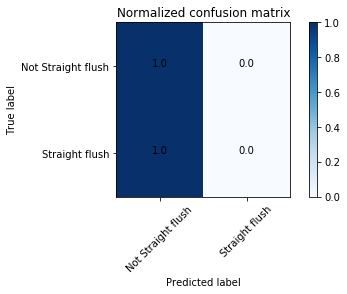

```python
# cnf_matrix = confusion_matrix(true_Y, predict_Y)
cnf_matrix = metrics.confusion_matrix(trues_now, predics_now)
np.set_printoptions(precision=2)
# Plot non-normalized confusion matrix
plt.figure()
plot_confusion_matrix(cnf_matrix, classes=["Not "+class_names[class_now], class_names[class_now]], normalize=False,
                      title='Normalized confusion matrix')
plt.show()
```

Com a parte mais escura do grafico ficando a esquerda, podemos ver que o modelo na maior parte das vezes preveu que a classe não era a classe em questão. Conseguiu acertar bastante quando não era realmente, mas errou na maior parte das vezes quando era da classe.

Pode se concluir que o modelo chutou muito pouco que um exemplo do dataset era dessa classe.

#### Acurácia

```python
metrics.accuracy_score(trues_now, predics_now)
```

```
0.99973599999999996
```

Com um taxa de acurácia de quase 100%, temos a impressão de que o modelo conseguiu acertar muito nessa classe. Mas como pudemos observar na matriz de confusão e vamos observar nas próximas métricas, isso muito se deu por ter muito exemplos que não fazem parte dessa classe no dataset e a predição ter tido uma porcentagem enorme de chutes em não ser da classe.

#### Precisão

```python
metrics.precision_score(trues_now, predics_now)
```

```
0.0
```

Com uma precisão 0% podemos afirmar que o modelo errou todos ao tentar prever a classe. Não houve nenhum verdadeiro positivo para a classe.

#### Recall

```python
metrics.recall_score(trues_now, predics_now)
```

```
0.0
```

Com uma recall 0% podemos afirmar que o modelo errou todos ao tentar prever a classe. Não houve nenhum verdadeiro positivo para a classe.

#### f1 Score

```python
metrics.f1_score(trues_now, predics_now)
```

```
0.0
```

Corroborando com as métricas anteriores, o f1 está de 0%.

### Métricas de Validação - Classe 9 (Royal Flush)

#### A classe:

A classe 9 é referente a mão que possui uma combinação de cartas que caracteriza a mão de poker chamada "Sequencia real do mesmo naipe". Essa classe se dá quando o jogador possui todas as cartas com o **rank** na maior sequencia possível e todas essas cartas são do mesmo **naipe**.

#### Matriz de Confusão

Abaixo temos os resultados da matriz de confusão.

```python
class_now = 9
trues_now = true_Y_by_class[1]
predics_now = predict_Y_by_class[class_now]

trues_now.shape
```

```
(1000000, 1)
```

```
Confusion matrix, without normalization
[[  1.00e+00   2.20e-04]
 [  1.00e+00   7.57e-05]]
```

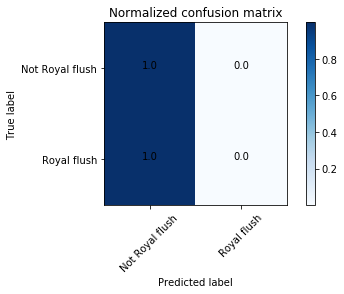

```python
# cnf_matrix = confusion_matrix(true_Y, predict_Y)
cnf_matrix = metrics.confusion_matrix(trues_now, predics_now)
np.set_printoptions(precision=2)
# Plot non-normalized confusion matrix
plt.figure()
plot_confusion_matrix(cnf_matrix, classes=["Not "+class_names[class_now], class_names[class_now]], normalize=False,
                      title='Normalized confusion matrix')
plt.show()
```

Com a parte mais escura do grafico ficando a esquerda, podemos ver que o modelo na maior parte das vezes preveu que a classe não era a classe em questão. Conseguiu acertar bastante quando não era realmente, mas errou na maior parte das vezes quando era da classe.

Pode se concluir que o modelo chutou muito pouco que um exemplo do dataset era dessa classe.

#### Acurácia

```python
metrics.accuracy_score(trues_now, predics_now)
```

```
0.577407
```

#### Precisão

```python
metrics.precision_score(trues_now, predics_now)
```

```
0.20125786163522014
```

#### Recall

```python
metrics.recall_score(trues_now, predics_now)
```

```
7.5740003502975162e-05
```

#### f1 Score

```python
metrics.f1_score(trues_now, predics_now)
```

```
0.00015142302150443504
```

Por o Recall estar muito abaixo da precisão, temos um f1 muito baixo. Próximo de 0%

### Métricas de Validação - Global

Aqui veremos algumas métricas globais do modelo.

#### Matriz de Confusão

Abaixo temos os resultados da matriz de confusão.

```
Confusion matrix, without normalization
[[  5.65e-01   3.74e-01   3.75e-02   1.54e-02   3.96e-03   2.35e-03
    9.80e-04   3.41e-04   2.06e-04   9.58e-05]
 [  4.16e-01   4.74e-01   7.28e-02   2.58e-02   6.03e-03   1.53e-03
    2.67e-03   4.52e-04   2.30e-04   7.57e-05]
 [  2.89e-01   5.36e-01   1.27e-01   3.33e-02   7.60e-03   6.72e-04
    5.42e-03   7.56e-04   1.47e-04   0.00e+00]
 [  2.80e-01   5.02e-01   8.60e-02   1.14e-01   9.09e-03   4.26e-04
    7.48e-03   1.28e-03   1.42e-04   1.42e-04]
 [  2.89e-01   5.22e-01   9.88e-02   4.61e-02   3.35e-02   1.80e-03
    4.12e-03   5.15e-04   2.83e-03   7.72e-04]
 [  4.36e-01   2.29e-01   1.90e-02   5.01e-03   6.01e-03   2.52e-01
    5.01e-04   0.00e+00   1.55e-02   3.66e-02]
 [  1.83e-01   5.34e-01   1.36e-01   1.06e-01   1.62e-02   0.00e+00
    2.32e-02   1.40e-03   0.00e+00   0.00e+00]
 [  1.30e-01   4.70e-01   2.04e-01   1.65e-01   1.30e-02   0.00e+00
    1.30e-02   4.35e-03   0.00e+00   0.00e+00]
 [  3.33e-01   2.50e-01   8.33e-02   0.00e+00   8.33e-02   2.50e-01
    0.00e+00   0.00e+00   0.00e+00   0.00e+00]
 [  0.00e+00   3.33e-01   0.00e+00   0.00e+00   0.00e+00   6.67e-01
    0.00e+00   0.00e+00   0.00e+00   0.00e+00]]
```

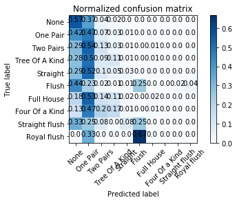

```python
# cnf_matrix = confusion_matrix(true_Y, predict_Y)
trues_now = true_Y
predics_now = predict_Y
cnf_matrix = metrics.confusion_matrix(true_Y, predict_Y)
np.set_printoptions(precision=2)
# Plot non-normalized confusion matrix
plt.figure()
plot_confusion_matrix(cnf_matrix, classes=class_names, normalize=False,
                      title='Normalized confusion matrix')
plt.show()
```

Analisando essa matriz de confusão global podemos ver com mais clareza quais foram as confusões cometidas pelo modelo.

Vemos claramente que a maior parte dos chutes foram para as classes **None** e **One Pair**, o que faz sentido pelas duas terem maior porcentagem de exemplos no dataset.

Percebemos também que o modelo confundiu a classe **Flush** com a classe **Royal Flush**. É um resultado que poderiamos esperar pela sobreposição de casos. O **Royal Flush** é um caso especial do **Flush**.

#### Acurácia

```python
metrics.accuracy_score(trues_now, predics_now)
```

```
0.49278300000000003
```

Com um taxa de acurácia de quase 49% e olhando para a matriz de confusão fica claro que a maior incidencia de classes de maior ocorrencia torna o modelo inviesado.

#### Precisão - Micro

```python
metrics.precision_score(trues_now, predics_now, average='micro')
```

```
0.49278300000000003
```

#### Precisão - Macro

```python
metrics.precision_score(trues_now, predics_now, average='macro')
```

```
0.15206826591586303
```

Uma precisão micro de quase 50% e uma macro de 15% torna evidente o que ja foi dito anteriormente. A maior ocorrencia de algumas classes no conjunto de teste fez a precisão micro se elevar enquanto a macro foi reduzida devido a baixissima precisão das demais classes.

#### Recall

##### Micro

```python
metrics.recall_score(trues_now, predics_now, average='micro')
```

```
0.49278300000000003
```

##### Macro

```python
metrics.recall_score(trues_now, predics_now, average='macro')
```

```
0.15932085563462711
```

Com o Recall ocorreu um fenomeno analogo ao da precisão.

#### f1 Score

#### Micro

```python
metrics.f1_score(trues_now, predics_now, average='micro')
```

```
0.49278300000000003
```

##### Macro

```python
metrics.f1_score(trues_now, predics_now, average='macro')
```

```
0.15519186881331573
```

O mesmo ocorreu com a médio f1.

## Conclusão

Através das métricas apresentadas anteriormente podemos afirmar que o modelo de predição do presente trabalho não foi bem sucedido. O modelo está claramente fazendo confusão de classes semelhantes, que possuem mais sobreposição de exemplos, e está chutando excedidas vezes as classes mais simples (None, One Pair), que possuem mais ocorrencia tanto no conjunto de treinamento quando no domínio do problema.

Os motivos das falhas podem ser diversos, mas arriscamos em afirmar que muito se dá por causa da grande dispersão de quantidade de exemplos no conjunto de treinamento. Vale lembrar que o conjunto de treinamento e de testes procura ser fiel ao domínio do problema real quanto a pocentagem de ocorrencia de uma determinada classe. Outro fator importante pode estar no algorítmo escolhido, a arvore de decisão é um algoritímo que cria regras para acertar o máximo possível, talvez por isso esteja dando preferencia em chutar valores de maior ocorrencia.

Então encerramos esse trabalho com a conclusão de que é necessário um estudo maior em cima do dataset, mais teste e mais esforço e tempo dedicados a esse problema. Com certeza será necessário um estudo maior de qual seria a separação de conjuntos teste-treino ideal para esse problema e quais algoritimos e parâmetros são os melhores.